# Pan-Cancer Classification Using Multi-Omic Synergy

## Visualizing the Feature Space (PCA vs. t-SNE)

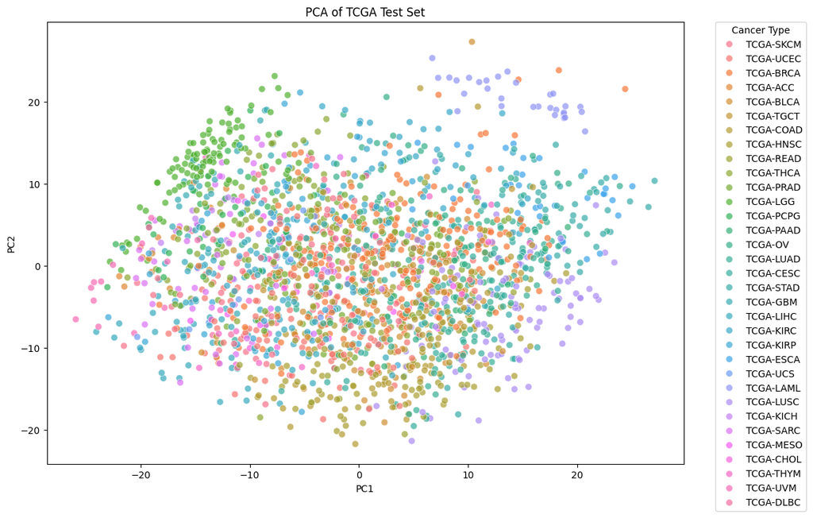

```python
# Plot PCA (Principal Component Analysis)
pca = PCA(n_components=2)
X_test_pca = pca.fit_transform(X_test_scaled)
pca_df = pd.DataFrame(data=X_test_pca, columns=['PC1', 'PC2'])
pca_df['Cancer Type'] = y_test.values

plt.figure(figsize=(12, 8))
sns.scatterplot(
    data=pca_df,
    x='PC1', y='PC2',
    hue='Cancer Type',
    alpha=0.7, s=50,
    legend='full'
)
plt.title('PCA of TCGA Test Set')
plt.legend(bbox_to_anchor=(1.05, 1), loc=2, borderaxespad=0., title='Cancer Type')
plt.tight_layout()
plt.show()
```

A linear PCA plot suggests the data has no clear separation or correlation amongst cancer types. However, a non-linear t-SNE visualization (below) shows a very different story: the 33 cancer types form highly distinct and separable clusters.

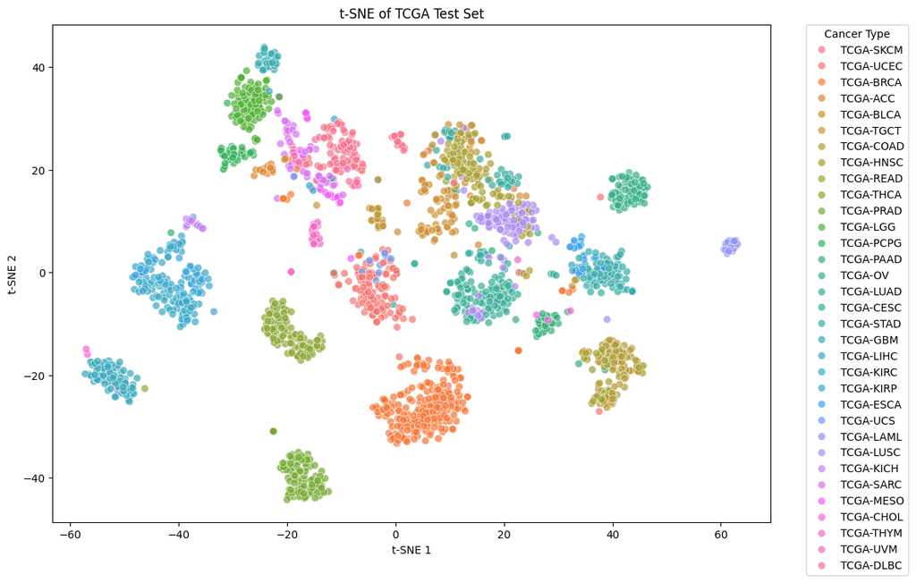

```python
# Plot t-SNE
tsne = TSNE(n_components=2, random_state=42, perplexity=30.0)
X_test_tsne = tsne.fit_transform(X_test_scaled)
tsne_df = pd.DataFrame(data=X_test_tsne, columns=['t-SNE 1', 't-SNE 2'])
tsne_df['Cancer Type'] = y_test.values

plt.figure(figsize=(12, 8))
sns.scatterplot(
    data=tsne_df,
    x='t-SNE 1', y='t-SNE 2',
    hue='Cancer Type',
    alpha=0.7, s=50,
    legend='full'
)
plt.title('t-SNE of TCGA Test Set')
plt.legend(bbox_to_anchor=(1.05, 1), loc=2, borderaxespad=0., title='Cancer Type')
plt.tight_layout()
plt.show()
```

This confirms that the data is highly informative and that a powerful classifier should be able to find the boundaries between these clusters.

## Baseline Feature Importance

We can inspect the baseline Random Forest model to see which genes it found most predictive. We use the Ensembl REST API to map the Ensembl IDs to human-readable gene symbols.

```
Querying Ensembl API for gene symbols...
Feature importance plot saved.
```

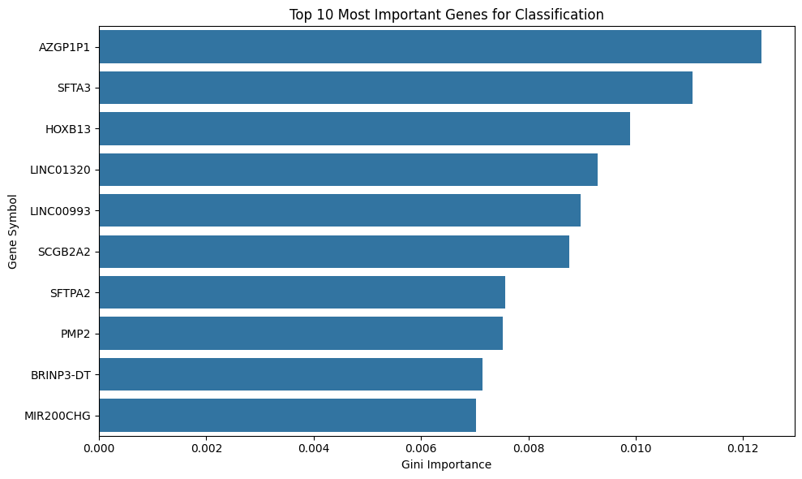

```python
# Get feature importances from the baseline model
importances = model.feature_importances_
feature_imp_df = pd.DataFrame({
    'Gene': X_top_1000.columns,
    'Importance': importances
}).sort_values(by='Importance', ascending=False)

# Get top 10 gene IDs (cleaned of version numbers)
top_10_ids = [gid.split('.')[0] for gid in feature_imp_df.head(10)['Gene']]

# Query Ensembl REST API to map IDs to symbols
print("Querying Ensembl API for gene symbols...")
server = "https://rest.ensembl.org"
ext = "/lookup/id"
headers = {"Content-Type": "application/json", "Accept": "application/json"}
data = json.dumps({"ids": top_10_ids})

r = requests.post(server + ext, headers=headers, data=data)
r.raise_for_status()
decoded = r.json()

gene_map = {}
for ensembl_id, info in decoded.items():
    symbol = info.get('display_name', ensembl_id) if info else ensembl_id
    gene_map[ensembl_id] = symbol

feature_imp_df['Gene Symbol'] = feature_imp_df['Gene'].apply(
    lambda x: gene_map.get(x.split('.')[0], x)
)

# Plot the Top 10 genes
plt.figure(figsize=(10, 6))
sns.barplot(
    data=feature_imp_df.head(10),
    x='Importance',
    y='Gene Symbol'
)
plt.title('Top 10 Most Important Genes for Classification')
plt.xlabel('Gini Importance')
plt.ylabel('Gene Symbol')
plt.tight_layout()
plt.savefig('feature_importance.png', dpi=300)
print("Feature importance plot saved.")
```